# 03_Killer_Graph

```r
#Load in tidyverse data: games
library(tidytuesdayR)
tt_data <- tt_load("2021-03-16")
```

```
--- Compiling #TidyTuesday Information for 2021-03-16 ----
--- There is 1 file available ---
--- Starting Download ---
```

```
--- Download complete ---
```

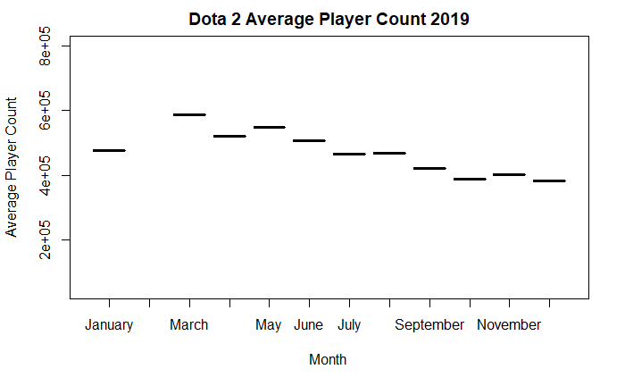

```r
#Assign "games" data to games_data
games_data = tt_data$games

#Extract out just data on the game Dota 2
dota2_data = games_data[games_data$gamename == "Dota 2",]

#Extract out just data on Dota in 2019
dota2_data_2019 = dota2_data[dota2_data$year == 2019,]

#Factor the months so they're in chronological order

month_factor  = factor(as.factor(dota2_data_2019$month),
                      levels=c("January", "Febuary", "March",
                               "April", "May", "June", "July",
                               "August", "September", "October",
                               "November", "December"))



plot(month_factor, dota2_data_2019$avg,
      xlab="Month ", ylab="Average Player Count", ylim=c(50000,800000))
title("Dota 2 Average Player Count 2019")
```

Here we are looking at the average player count of the game Dota 2 during 2019. 2019 is an interesting year when compared to the previous 3 years (listed below).

As you can see, the previous 3 years exhibits a similar pattern while 2019 is more wild.

The most noteworthy is just how stable the average player count is for previous 3 yeaers. Another is that near the end of summer(Aug, September), there is a big Dota 2 tournament called The International(TI). Valve(The game developer) does alot of things in the summer to promote it, so there is usually a jump in the player base. Along with other factors like summer break etc.

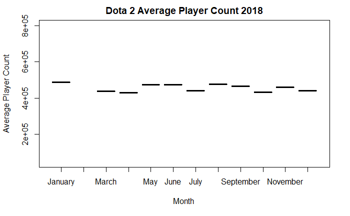

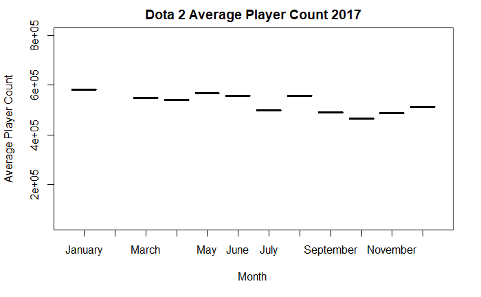

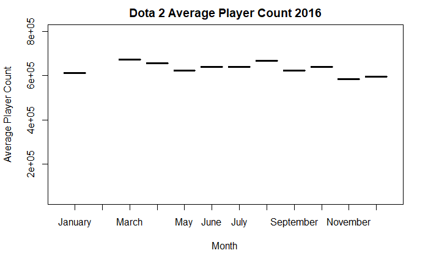

```r
for (x in c(2018,2017,2016)){
  dota2_data_year = dota2_data[dota2_data$year == x,]

  plot(month_factor, dota2_data_year$avg,
      xlab="Month ", ylab="Average Player Count", ylim=c(50000,800000))
  titles<- paste(c("Dota 2 Average Player Count ", x), collapse = "")
  title(titles)

}
```

[figure not shown]

```r
dota2_data_year = dota2_data[dota2_data$year == 2020,]

plot(month_factor, dota2_data_year$avg,
    xlab="Month ", ylab="Average Player Count", ylim=c(50000,800000))
titles<- paste(c("Dota 2 Average Player Count ", x), collapse = "")
title(titles)
```

[output not shown]

```r
NA
NA
```